# SpatialData.Rmd

Witold Wolski

May 5, 2017

```r
install.packages(c("sp","plotGoogleMaps","spatstat","raster","maptools","plotrix","rgeos"))
```

# What is spatstats

- Implement functionality
- Hanlde real datasets
  - Example Ripley redwood data
  - Ants Data
- Fit realistic models to data.
  - spatial point patterns is conducted almost exclusively using ‘exploratory’ summary statistics such as the K function
  - fit parametric models to spatial point pattern data
- Creation, manipulation and plotting of point patterns
  - extracting subsets
- Exploratory data analysis
  - the average intensity,
  - the K function Ripley (1977) and the
  - kernel-smoothed intensity map
  - empty space function F,
  - nearest neighbour distance function G,
  - pair correlation function g,
  - inhomogeneous K function
  - second moment measure,
  - Bartlett spectrum,
  - cross-K function,
  - cross-G function,
  - J-function
  - mark correlation function.
- Parametric model-fitting:
  - The point process models to be fitted may be quite general Gibbs/Markov models
  - A fitted model can be printed, plotted, predicted, updated, and simulated. Capabilities for residual analysis and model diagnostics will be added in version 1.6.
  - Models are specified using a formula in the R language
  - printed, plotted, predicted, updated, and simulated

```r
data <- read.csv("http://www.fabioveronesi.net/Blog/2014-05-metropolitan-street.csv")
head(data)
write.csv(data, file="Data/OriginalDataOfFabio.csv")
```

```r
data <- read.csv("Data/OriginalDataOfFabio.csv")
str(data)
```

```
## 'data.frame':    79832 obs. of  13 variables:
##  $ X                    : int  1 2 3 4 5 6 7 8 9 10 ...
##  $ Crime.ID             : Factor w/ 55285 levels "","0000782cea7b25267bfc4d22969498040d991059de4ebc40385be66e3ecc3c73",..: 1 1 1 1 1 2926 28741 19664 45219 21769 ...
##  $ Month                : Factor w/ 1 level "2014-05": 1 1 1 1 1 1 1 1 1 1 ...
##  $ Reported.by          : Factor w/ 1 level "Metropolitan Police Service": 1 1 1 1 1 1 1 1 1 1 ...
##  $ Falls.within         : Factor w/ 1 level "Metropolitan Police Service": 1 1 1 1 1 1 1 1 1 1 ...
##  $ Longitude            : num  0.141 0.137 0.14 0.136 0.135 ...
##  $ Latitude             : num  51.6 51.6 51.6 51.6 51.6 ...
##  $ Location             : Factor w/ 20462 levels "No Location",..: 15099 14596 1503 1919 12357 1503 8855 14060 8855 8855 ...
##  $ LSOA.code            : Factor w/ 4864 levels "","E01000002",..: 24 24 24 24 24 24 24 24 24 24 ...
##  $ LSOA.name            : Factor w/ 4864 levels "","Barking and Dagenham 001A",..: 2 2 2 2 2 2 2 2 2 2 ...
##  $ Crime.type           : Factor w/ 14 levels "Anti-social behaviour",..: 1 1 1 1 1 3 3 5 7 7 ...
##  $ Last.outcome.category: Factor w/ 23 levels "","Awaiting court outcome",..: 1 1 1 1 1 21 8 21 8 8 ...
##  $ Context              : logi  NA NA NA NA NA NA ...
```

```r
data <- data[!is.na(data$Longitude)&!is.na(data$Latitude),]
```

# Point pattern analysis

A point process is a stochastic process for which we observe its results, or events, only in a specific region, which is the area under study, or simply window. The location of the events is a point pattern (Bivand et al., 2008). In R the package for Point Pattern Analysis is spatstat, which works with its own format (i.e. ppp). There are ways to transform a data.frame into a ppp object, however in this case we have a problem. The crime dataset contains lots of duplicated locations. We can check this by first transform data into a SpatialObject and then use the function zerodist to check for duplicated locations:

```r
coordinates(data)=~Longitude+Latitude
zero <- zerodist(data)
class(zero)
```

```
## [1] "matrix"
```

```r
length(unique(zero[,1]))
```

```
## [1] 47920
```

# Loading Natural Earth Provinces dataset to define window for Point Pattern Analysis

There is also another potential issue with this dataset. Even though the large majority of crimes are reported for London, some of them (n=660) are also located in other areas. Since these crimes are a small fraction of the total I do not think it makes much sense to include them in the analysis, so we need to remove them. To do so we need to import a shapefile with the borders of the Greater London region. Natural Earth provides this sort of data, since it distributes shapefiles at various resolution. For this analysis we would need the following dataset: Admin 1 – States, Provinces

To download it and import it in R we can use the following lines:

```r
download.file("http://www.naturalearthdata.com/http//www.naturalearthdata.com/download/10m/cultural/ne_10m_admin_1_states_provinces.zip",destfile="ne_10m_admin_1_states_provinces.zip")
unzip("ne_10m_admin_1_states_provinces.zip",exdir="NaturalEarth")
```

```r
border <- shapefile("NaturalEarth/ne_10m_admin_1_states_provinces.shp")
```

To extract only the border of the Greater London regions we can simply subset the SpatialPolygons object as follows:

```r
GreaterLondon <- border[paste(border$region)=="Greater London",]
```

Now we need to overlay it with crime data and then eliminate all the points that do not belong to the Greater London region. To do that we can use the following code:

```r
#Extract crimes in London
projection(data)=projection(border)
overlay <- over(data,GreaterLondon)

data$over <- overlay$OBJECTID_1

data.London <- data[!is.na(data$over),]
```

# Simple Plot

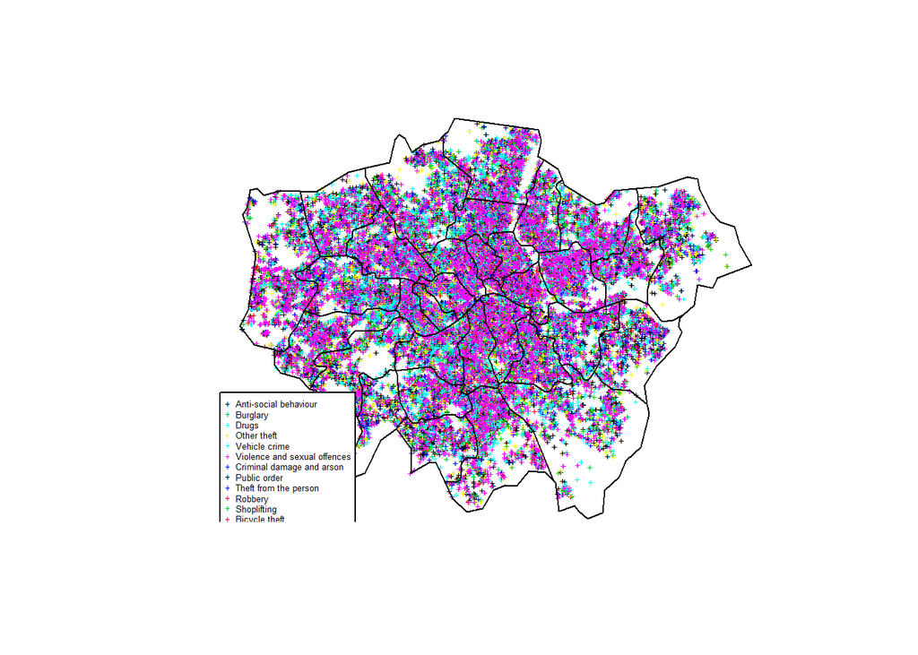

```r
#jpeg("PP_plot.jpg",2500,2000,res=300)
plot(data.London,pch="+",cex=0.5,main="",col=data.London$Crime.type)
plot(GreaterLondon,add=T)
legend(x=-0.53,y=51.41,pch="+",col=unique(data.London$Crime.type),legend=unique(data.London$Crime.type),cex=0.4)
```

```r
#dev.off()
```

# Summary statistics for point patterns

# The coordinates of the mean center are simply the mean value of X and Y

# therefore we can use the function mean() to determine their value

```r
mean_centerX <- mean(data.London@coords[,1])
mean_centerY <- mean(data.London@coords[,2])
```

# Similarly we can use the function sd() to determine the standard deviation of X and Y

```r
standard_deviationX <- sd(data.London@coords[,1])
standard_deviationY <- sd(data.London@coords[,2])
```

# This is the formula to compute the standard distance

```r
standard_distance <- sqrt(sum(((data.London@coords[,1]-mean_centerX)^2+(data.London@coords[,2]-mean_centerY)^2))/(nrow(data.London)))
```

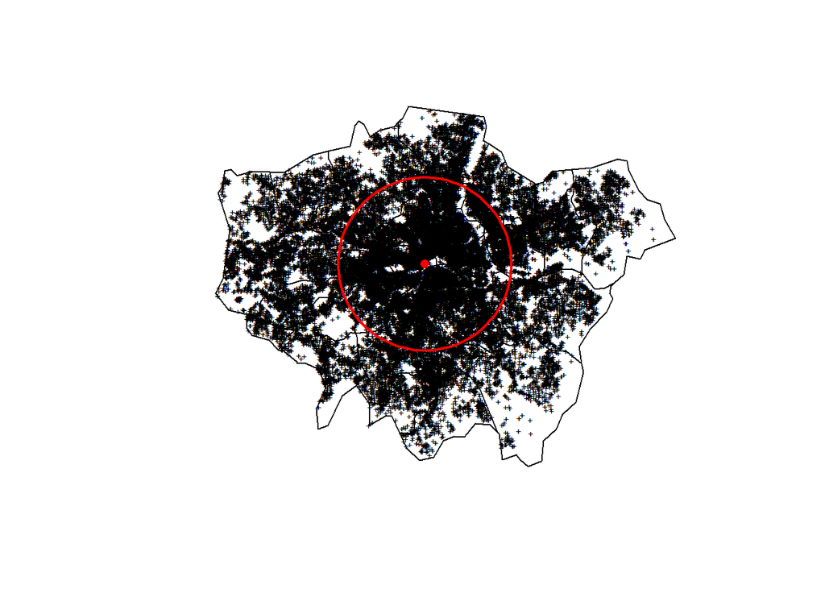

```r
plot(data.London,pch="+",cex=0.5,main="")
plot(GreaterLondon,add=T)
points(mean_centerX,mean_centerY,col="red",pch=16)
draw.circle(mean_centerX,mean_centerY,radius=standard_distance,border="red",lwd=2)
```

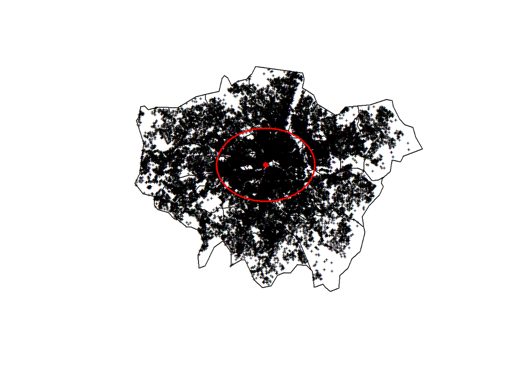

```r
plot(data.London,pch="+",cex=0.5,main="")
plot(GreaterLondon,add=T)
points(mean_centerX,mean_centerY,col="red",pch=16)
draw.ellipse(mean_centerX,mean_centerY,a=standard_deviationX,b=standard_deviationY,border="red",lwd=2)
```

# Working with spatstat

```r
Drugs <- data.London[data.London$Crime.type==unique(data.London$Crime.type)[3],]
Drugs <- remove.duplicates(Drugs)
```

# Transform GreaterLondon in UTM

```r
GreaterLondonUTM <- spTransform(GreaterLondon,CRS("+init=epsg:32630"))
Drugs.UTM <- spTransform(Drugs,CRS("+init=epsg:32630"))
```

# Transforming the SpatialPolygons object into an owin object for spatstat, using a function in maptools

```r
window <- as.owin(GreaterLondonUTM)
```